# Simulation-Based Power Analysis

Part 8: Power analysis across varying sample sizes and effect sizes — Handout

Author

Affiliation

Filip Andras, David López-García & David Sánchez Casasola

Centro de Investigación Mente Cerebro y Comportamiento (CIMCYC), Universidad de Granada

Published

26 May 2026

# 1 From a point estimate to a power curve

Up to Part 7 we have computed power at **one specific combination** of design parameters (n, effect size, number of items, random-effects variances). That is useful but limited.

The standard deliverable for a sample-size justification — in a research proposal, a pre-registration, or a grant — is a **power curve**: power estimates across a range of sample sizes, often for several plausible effect sizes.

In this part we build:

- A **first power grid**: power as a function of N subjects, for three effect sizes.
- A **second power grid**: power as a function of both N subjects and N items, for a fixed (small) effect size.

# 2 Recap of the generative model and one-dataset workflow

The data-generating function from Part 7:

```r
# 7 model parameters (all on log scale):
b0       <- 6.59  # grand mean log(RT); exp(6.59) ~ 730 ms
b1       <- 0.10  # log-scale frequency effect (~70 ms on RT scale)
sigma_u0 <- 0.2   # SD of subject random intercepts
sigma_u1 <- 0.02  # SD of subject random slopes
rho      <- -0.5  # correlation between subject intercepts and slopes
sigma_w  <- 0.1   # SD of item random intercepts
sigma    <- 0.25  # residual SD
```

We will walk through generating one dataset step by step to make sure the pieces are clear, then wrap everything in `gendat_ldt_crossed_log()` and start iterating.

```r
gendat_ldt_crossed_log <- function(n        = 20,
                                   k        = 20,
                                   b0       = 6.59,
                                   b1       = 0.10,
                                   sigma_u0 = 0.2,
                                   sigma_u1 = 0.02,
                                   rho      = -0.5,
                                   sigma_w  = 0.1,
                                   sigma    = 0.25) {

  sim_dat          <- expand.grid(item = 1:(k * 2), subj = 1:n)
  sim_dat$cond.cod <- rep(c(-0.5, 0.5), each = k)

  Sigma_u <- matrix(c(sigma_u0^2,                  rho * sigma_u0 * sigma_u1,
                      rho * sigma_u0 * sigma_u1,   sigma_u1^2),
                    nrow = 2)
  u <- mvrnorm(n = length(unique(sim_dat$subj)), mu = c(0, 0), Sigma = Sigma_u)
  w <- rnorm(n  = length(unique(sim_dat$item)), mean = 0, sd = sigma_w)

  N  <- dim(sim_dat)[1]
  rt <- rep(NA, N)
  for (i in 1:N) {
    rt[i] <- rlnorm(1,
                    b0 +
                    u[sim_dat[i, ]$subj, 1] +
                    w[sim_dat[i, ]$item] +
                    (b1 + u[sim_dat[i, ]$subj, 2]) * sim_dat[i, ]$cond.cod,
                    sigma)
  }

  sim_dat$rt   <- rt
  sim_dat$subj <- factor(sim_dat$subj)
  sim_dat$item <- factor(sim_dat$item)
  sim_dat
}
```

## 2.1 Sanity check on the generator

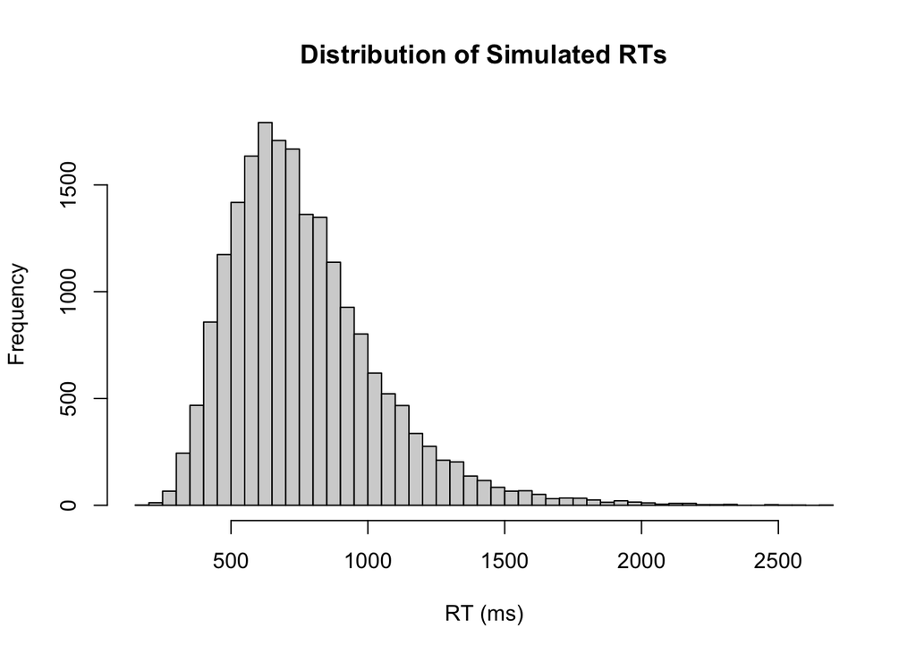

Figure 1: Simulated RTs from the log-normal generator (n = 100, k = 100 items per condition). Right-skewed as expected.

```r
sim_dat <- gendat_ldt_crossed_log(n = 100, k = 100)
hist(sim_dat$rt, breaks = 50,
     main = "Distribution of Simulated RTs",
     xlab = "RT (ms)")
```

## 2.2 Optional: a fancier visualisation

A raincloud plot combining density, boxplot, subject means, and individual trajectories:

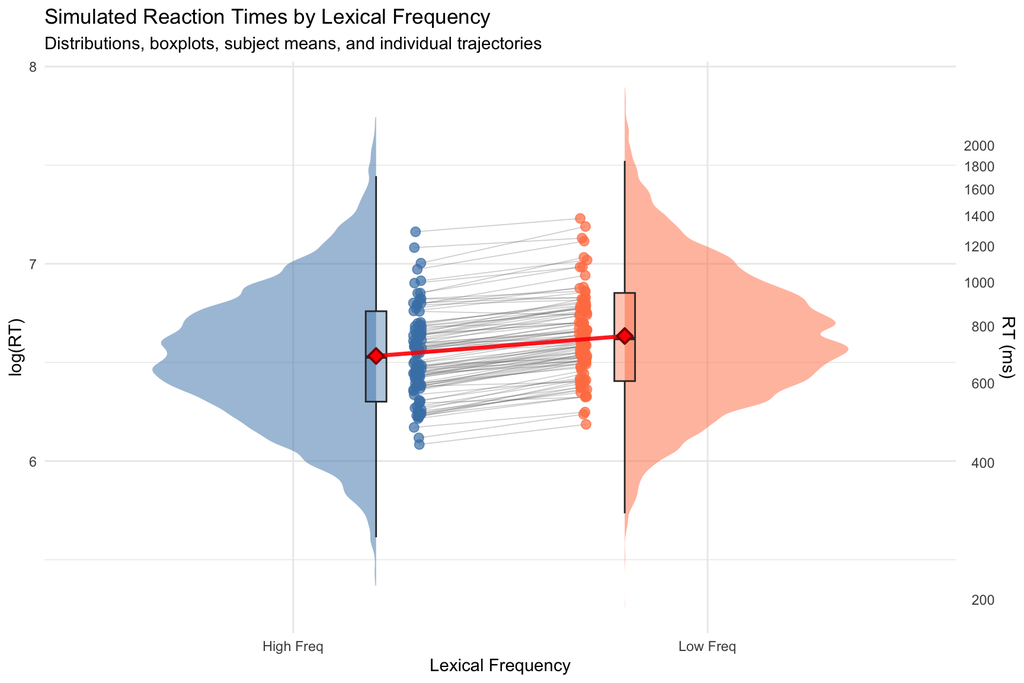

Figure 2: Raincloud plot of simulated log(RT) by condition. Half-violin shows the trial-level density, boxplot the IQR, points are subject means, lines connect each subject’s mean across conditions, and the red diamond + line marks the grand mean per condition.

## 2.3 Sanity check on the model

Fit the model once and verify the fixed-effect estimates are near the true generating values:

```r
m <- lmer(log(rt) ~ cond.cod + (1 + cond.cod | subj) + (1 | item), sim_dat,
          control = lmerControl(calc.derivs = FALSE))
summary(m)
```

```
Linear mixed model fit by REML. t-tests use Satterthwaite's method ['lmerModLmerTest']
Formula: log(rt) ~ cond.cod + (1 + cond.cod | subj) + (1 | item)
   Data: sim_dat
Control: lmerControl(calc.derivs = FALSE)

REML criterion at convergence: 2679.4

Scaled residuals:
    Min      1Q  Median      3Q     Max
-4.0033 -0.6705  0.0082  0.6736  4.0879

Random effects:
 Groups   Name        Variance  Std.Dev. Corr
 item     (Intercept) 0.0087705 0.09365
 subj     (Intercept) 0.0436861 0.20901
          cond.cod    0.0006833 0.02614  -0.23
 Residual             0.0634199 0.25183
Number of obs: 20000, groups:  item, 200; subj, 100

Fixed effects:
             Estimate Std. Error        df t value             Pr(>|t|)
(Intercept)   6.58337    0.02200 119.03702 299.280 < 0.0000000000000002 ***
cond.cod      0.10119    0.01396 208.16071   7.248     0.00000000000815 ***
---
Signif. codes:  0 '***' 0.001 '**' 0.01 '*' 0.05 '.' 0.1 ' ' 1

Correlation of Fixed Effects:
         (Intr)
cond.cod -0.040
```

# 3 Two power grids

We build two complementary power grids, presented in parallel tabs below.

The **first grid** varies subjects × effect sizes (with items fixed) — this is the standard “how many subjects do I need at each plausible effect size?” question. The **second grid** varies subjects × items (with effect size fixed at the small value) — useful when stimulus pool size is a design lever you control, common in psycholinguistics.

Both grids share the same machinery: build a parameter grid, run a nested power-simulation loop, load the precomputed result, compute Clopper-Pearson confidence intervals on each power estimate, and visualise. Each tab is self-contained.

**Note**

**Confidence intervals on power.** Each power estimate is the proportion of `nsim` independent significant results — a binomial proportion. The Clopper-Pearson method gives an *exact* confidence interval for that proportion. We define the helper `calculate_power_ci()` once here and reuse it in both tabs.

**Show code (CI helper function)**

```r
calculate_power_ci <- function(n_significant, n_total, conf.level = 0.95) {
  if (is.na(n_significant) || is.na(n_total) || n_total == 0) {
    return(c(power = NA, lower = NA, upper = NA))
  }
  n_significant <- as.integer(round(n_significant))
  n_total       <- as.integer(round(n_total))
  if (n_significant < 0)        n_significant <- 0
  if (n_significant > n_total)  n_significant <- n_total

  test_result <- binom.test(n_significant, n_total, conf.level = conf.level)
  c(power = unname(test_result$estimate),
    lower = test_result$conf.int[1],
    upper = test_result$conf.int[2])
}
```

**First grid: subjects × effect sizes**

The first power curve varies the number of subjects across three effect sizes, with items fixed at 40 per condition:

```r
n_subj       <- c(24, 36, 48, 60, 72, 84, 96)
effect_sizes <- c(0.06, 0.10, 0.14)
n_item       <- 40  # fixed number of items per condition

power_grid       <- expand.grid(n = n_subj, b1 = effect_sizes)
power_grid$power <- NA
power_grid
```

```
    n   b1 power
1  24 0.06    NA
2  36 0.06    NA
3  48 0.06    NA
4  60 0.06    NA
5  72 0.06    NA
6  84 0.06    NA
7  96 0.06    NA
8  24 0.10    NA
9  36 0.10    NA
10 48 0.10    NA
11 60 0.10    NA
12 72 0.10    NA
13 84 0.10    NA
14 96 0.10    NA
15 24 0.14    NA
16 36 0.14    NA
17 48 0.14    NA
18 60 0.14    NA
19 72 0.14    NA
20 84 0.14    NA
21 96 0.14    NA
```

Each row of `power_grid` is one (n, effect) combination. We will fill in the `power` column by running `nsim = 1000` simulations per row.

```r
nsim <- 1000
nrow(power_grid)         # number of (n, effect) combinations
```

```
[1] 21
```

```r
nrow(power_grid) * nsim  # total number of model fits
```

```
[1] 21000
```

**Warning**

21,000 model fits is a lot of computation. The full first grid takes **~5.34 hours** on a standard laptop. Below we show the loop code (set to `eval: false`) and instead load the precomputed result.

### 3.0.1 The simulation loop

```r
tic()
for (row in 1:nrow(power_grid)) {
  n_subj <- power_grid$n[row]
  effect <- power_grid$b1[row]

  message(sprintf("Running: n=%d, b1=%.2f (%d/%d)",
                  n_subj, effect, row, nrow(power_grid)))

  pvals <- rep(NA, nsim)
  for (i in 1:nsim) {
    sim_dat <- gendat_ldt_crossed_log(n = n_subj, k = n_item,
                                      b0 = 6.59, b1 = effect,
                                      sigma_u0 = 0.2, sigma_u1 = 0.02,
                                      rho = -0.5, sigma_w = 0.1, sigma = 0.25)
    m <- lmer(log(rt) ~ cond.cod + (1 + cond.cod | subj) + (1 | item), sim_dat,
              control = lmerControl(calc.derivs = FALSE))
    pvals[i] <- summary(m)$coefficients[2, 5]
  }
  power_grid$power[row] <- mean(pvals < 0.05)
}
toc() # 19246.916 sec elapsed = 5.34h

# save(power_grid, file = "../data/processed_data/power_grid_sub_eff.RData")
```

### 3.0.2 Load the precomputed result

```r
load("../data/processed_data/power_grid_sub_eff.RData")
power_grid
```

```
    n   b1 power
1  24 0.06 0.630
2  36 0.06 0.697
3  48 0.06 0.693
4  60 0.06 0.689
5  72 0.06 0.721
6  84 0.06 0.713
7  96 0.06 0.731
8  24 0.10 0.966
9  36 0.10 0.989
10 48 0.10 0.991
11 60 0.10 0.989
12 72 0.10 0.987
13 84 0.10 0.996
14 96 0.10 0.996
15 24 0.14 1.000
16 36 0.14 1.000
17 48 0.14 1.000
18 60 0.14 1.000
19 72 0.14 1.000
20 84 0.14 1.000
21 96 0.14 1.000
```

### 3.0.3 Add confidence intervals

**Show code (CI computation)**

```r
power_grid$n_sig    <- round(power_grid$power * nsim)
power_grid$lower_ci <- NA
power_grid$upper_ci <- NA

for (row in 1:nrow(power_grid)) {
  ci <- calculate_power_ci(power_grid$n_sig[row], nsim)
  power_grid$lower_ci[row] <- ci["lower"]
  power_grid$upper_ci[row] <- ci["upper"]
}

print(power_grid[, c("n", "b1", "power", "lower_ci", "upper_ci")])
```

```
    n   b1 power  lower_ci  upper_ci
1  24 0.06 0.630 0.5992283 0.6600038
2  36 0.06 0.697 0.6674670 0.7253680
3  48 0.06 0.693 0.6633742 0.7214846
4  60 0.06 0.689 0.6592838 0.7175987
5  72 0.06 0.721 0.6920786 0.7486138
6  84 0.06 0.713 0.6838642 0.7408758
7  96 0.06 0.731 0.7023621 0.7582708
8  24 0.10 0.966 0.9528106 0.9763414
9  36 0.10 0.989 0.9804034 0.9944964
10 48 0.10 0.991 0.9829842 0.9958766
11 60 0.10 0.989 0.9804034 0.9944964
12 72 0.10 0.987 0.9778722 0.9930604
13 84 0.10 0.996 0.9897903 0.9989091
14 96 0.10 0.996 0.9897903 0.9989091
15 24 0.14 1.000 0.9963179 1.0000000
16 36 0.14 1.000 0.9963179 1.0000000
17 48 0.14 1.000 0.9963179 1.0000000
18 60 0.14 1.000 0.9963179 1.0000000
19 72 0.14 1.000 0.9963179 1.0000000
20 84 0.14 1.000 0.9963179 1.0000000
21 96 0.14 1.000 0.9963179 1.0000000
```

The CIs are narrow because `nsim = 1000` is large. More simulations would give narrower CIs but at the cost of more compute time.

### 3.0.4 Visualisation: power curves

**Show code (ggplot recipe)**

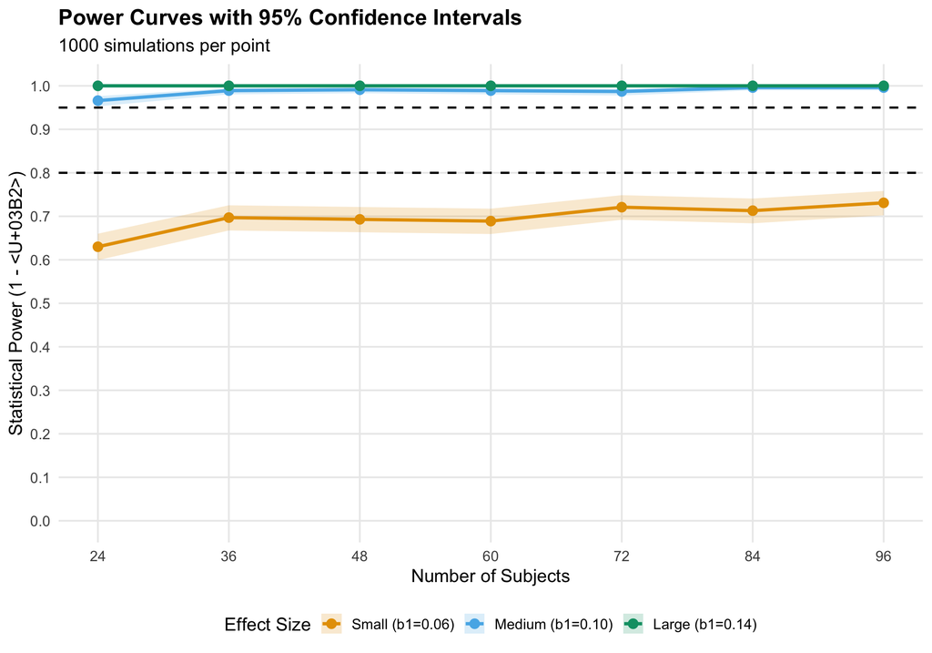

Figure 3: Power curves with 95% Clopper-Pearson CIs for three effect sizes, as a function of subject sample size (40 items per condition).

```r
power_grid$effect_label <- factor(power_grid$b1,
                                  levels = c(0.06, 0.10, 0.14),
                                  labels = c("Small (b1=0.06)",
                                             "Medium (b1=0.10)",
                                             "Large (b1=0.14)"))

ggplot(power_grid, aes(x = n, y = power,
                       color = effect_label, fill = effect_label,
                       group = effect_label)) +
  geom_ribbon(aes(ymin = lower_ci, ymax = upper_ci),
              alpha = 0.2, color = NA) +
  geom_line(linewidth = 1.2) +
  geom_point(size = 3) +
  geom_hline(yintercept = 0.80, linetype = "dashed", color = "black", linewidth = 0.8) +
  geom_hline(yintercept = 0.95, linetype = "dashed", color = "black", linewidth = 0.8) +
  scale_y_continuous(limits = c(0, 1), breaks = seq(0, 1, 0.1)) +
  scale_x_continuous(breaks = n_subj) +
  scale_color_manual(values = c("#E69F00", "#56B4E9", "#009E73")) +
  scale_fill_manual(values  = c("#E69F00", "#56B4E9", "#009E73")) +
  labs(title    = "Power Curves with 95% Confidence Intervals",
       subtitle = sprintf("%d simulations per point", nsim),
       x        = "Number of Subjects",
       y        = "Statistical Power (1 - β)",
       color    = "Effect Size",
       fill     = "Effect Size") +
  theme_minimal(base_size = 14) +
  theme(legend.position  = "bottom",
        plot.title       = element_text(face = "bold"),
        panel.grid.minor = element_blank())
```

How to read this plot:

- **x-axis**: number of subjects.
- **y-axis**: power. Dashed lines mark the 80% and 95% conventional targets.
- **Three curves**: power as a function of subjects for the three effect sizes.
- **Shaded ribbons**: 95% Clopper-Pearson CIs on each power estimate.

**Second grid: subjects × items (small effect)**

What if we instead want to understand how the **number of items per condition** trades off against the number of subjects, for a fixed (small) effect?

```r
sample_sizes_2d <- c(24, 36, 48, 60, 72, 84, 96)
item_numbers_2d <- c(40, 60, 80, 100, 120)
effect_fixed    <- 0.06

power_grid_2d       <- expand.grid(n = sample_sizes_2d, nitem = item_numbers_2d)
power_grid_2d$power <- NA

nsim <- 500 # fewer simulations per cell for this larger grid
nrow(power_grid_2d) * nsim  # total simulations
```

```
[1] 17500
```

**Warning**

This second grid covers $7 \times 5 = 35$ cells with 500 simulations each — 17,500 model fits. It took **~8.37 hours** to run, so once again we show the loop and load the precomputed result.

### 3.0.5 The simulation loop

```r
tic()
for (row in 1:nrow(power_grid_2d)) {
  n_subj  <- power_grid_2d$n[row]
  n_items <- power_grid_2d$nitem[row]

  message(sprintf("Running: n=%d, k=%d (%d/%d)",
                  n_subj, n_items, row, nrow(power_grid_2d)))

  pvals <- rep(NA, nsim)
  for (i in 1:nsim) {
    sim_dat <- gendat_ldt_crossed_log(n = n_subj, k = n_items,
                                      b0 = 6.59, b1 = effect_fixed,
                                      sigma_u0 = 0.2, sigma_u1 = 0.02,
                                      rho = -0.5, sigma_w = 0.1, sigma = 0.25)
    m <- lmer(log(rt) ~ cond.cod + (1 + cond.cod | subj) + (1 | item), sim_dat,
              control = lmerControl(calc.derivs = FALSE))
    pvals[i] <- summary(m)$coefficients[2, 5]
  }
  power_grid_2d$power[row] <- mean(pvals < 0.05)
}
toc() # 30145.484 sec elapsed = 8.37h

# save(power_grid_2d, file = "../data/processed_data/power_grid_2d.RData")
```

### 3.0.6 Load the precomputed result

```r
load("../data/processed_data/power_grid_2d.RData")
power_grid_2d
```

```
    n nitem power
1  24    40 0.650
2  36    40 0.660
3  48    40 0.704
4  60    40 0.728
5  72    40 0.702
6  84    40 0.730
7  96    40 0.734
8  24    60 0.798
9  36    60 0.852
10 48    60 0.836
11 60    60 0.888
12 72    60 0.846
13 84    60 0.862
14 96    60 0.882
```

[output cut: 21 more lines]

### 3.0.7 Add confidence intervals

**Show code (CI computation)**

```r
nsim <- 500 # matches the simulation budget for the second grid

power_grid_2d$n_sig    <- round(power_grid_2d$power * nsim)
power_grid_2d$lower_ci <- NA
power_grid_2d$upper_ci <- NA

for (row in 1:nrow(power_grid_2d)) {
  if (!is.na(power_grid_2d$power[row])) {
    ci <- calculate_power_ci(power_grid_2d$n_sig[row], nsim)
    power_grid_2d$lower_ci[row] <- ci["lower"]
    power_grid_2d$upper_ci[row] <- ci["upper"]
  }
}

power_grid_2d[, c("n", "nitem", "power", "lower_ci", "upper_ci")]
```

```
    n nitem power  lower_ci  upper_ci
1  24    40 0.650 0.6064011 0.6918131
2  36    40 0.660 0.6166258 0.7014690
3  48    40 0.704 0.6618638 0.7437044
4  60    40 0.728 0.6867224 0.7665575
5  72    40 0.702 0.6597983 0.7417938
6  84    40 0.730 0.6888002 0.7684556
7  96    40 0.734 0.6929588 0.7722489
8  24    60 0.798 0.7600903 0.8323421
9  36    60 0.852 0.8177996 0.8819672
10 48    60 0.836 0.8005771 0.8673886
11 60    60 0.888 0.8570315 0.9142794
12 72    60 0.846 0.8113275 0.8765140
13 84    60 0.862 0.8286253 0.8910161
14 96    60 0.882 0.8504396 0.9089483
```

[output cut: 21 more lines]

### 3.0.8 Visualisation: heatmap

**Show code (ggplot recipe)**

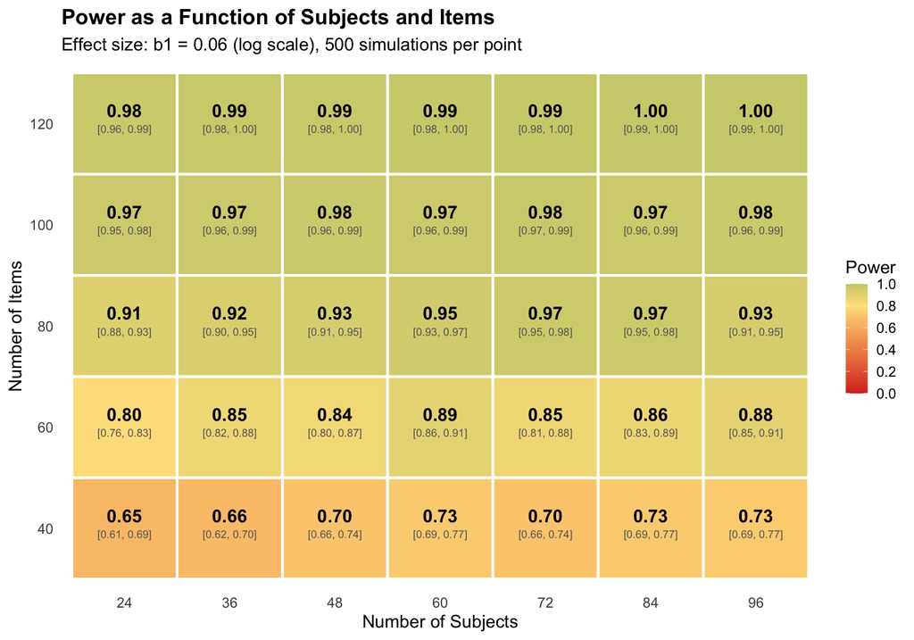

Figure 4: Heatmap of power as a function of subjects and items, for a small effect (b1 = 0.06 on the log scale). Green cells are at or above 80% power; orange/red cells are below. Bracket values are the 95% Clopper-Pearson CIs.

```r
ggplot(power_grid_2d, aes(x = factor(n), y = factor(nitem), fill = power)) +
  geom_tile(color = "white", size = 1) +
  geom_text(aes(label = sprintf("%.2f", power)),
            color = "black", size = 5, fontface = "bold", vjust = -0.5) +
  geom_text(aes(label = sprintf("[%.2f, %.2f]", lower_ci, upper_ci)),
            color = "grey40", size = 3, vjust = 1.2) +
  scale_fill_gradient2(low      = "#d73027",
                       mid      = "#fee08b",
                       high     = "#1a9850",
                       midpoint = 0.80,
                       limits   = c(0, 1),
                       breaks   = seq(0, 1, 0.2),
                       name     = "Power") +
  labs(title    = "Power as a Function of Subjects and Items",
       subtitle = sprintf("Effect size: b1 = %.2f (log scale), %d simulations per point",
                          effect_fixed, nsim),
       x = "Number of Subjects",
       y = "Number of Items") +
  theme_minimal(base_size = 14) +
  theme(plot.title  = element_text(face = "bold"),
        panel.grid  = element_blank())
```

The heatmap shows that **both** axes matter. To detect a small effect with adequate power, you can either run many subjects with moderate items, or fewer subjects with many items. The corner of the grid (96 subjects × 120 items per condition) is the easiest case.

# 4 What to do next

The power analysis above is intentionally coarse — three effect sizes in the first grid, seven subject counts × five item counts in the second. For an actual study planning exercise:

- **Zoom in** on the range of (subjects, items) where you cross the 80% or 95% threshold.
- **Run more simulations per cell** (e.g., 2000+ instead of 500) to tighten the CIs.
- **Refine the input parameters** ($\sigma_{u0}, \sigma_{u1}, \rho, \sigma_w, \sigma$) from a pilot dataset rather than relying on values from the literature — they are the single biggest source of uncertainty in the result.

# 5 The final model

After eight parts we have built up a full data-generating process and a matching LMM:

$$\log(rt_{ij}) = \beta_0 + u_{0i} + w_{0j} + (\beta_1 + u_{1i}) \times \text{cond.cod}_{ij} + \varepsilon_{ij}$$

where $\varepsilon_{ij} \sim \text{Normal}(0, \sigma)$,

$$\begin{pmatrix} u_0 \\ u_1 \end{pmatrix} \sim \text{MVN} \left(
\begin{pmatrix} 0 \\ 0 \end{pmatrix}, \, \Sigma_u \right), \quad
\Sigma_u = \begin{pmatrix}
\sigma_{u0}^2 & \rho \, \sigma_{u0} \sigma_{u1} \\
\rho \, \sigma_{u0} \sigma_{u1} & \sigma_{u1}^2
\end{pmatrix},$$

and $w_0 \sim \text{Normal}(0, \sigma_w)$.

Corresponding `lmer()` formula:

```r
lmer(log(rt) ~ cond.cod + (1 + cond.cod | subj) + (1 | item), data = ...)
```

# 6 Where to go next

This course covered simulation-based power analysis in R using `lme4`. Two recommended next steps:

- **Vasishth & Nicenboim**, *Using simulation to understand your model* — [Freq_CogSci](https://vasishth.github.io/Freq_CogSci/using-simulation-to-understand-your-model.html). Same paradigm, more examples, written for psycholinguistics.
- **Julia + MixedModelsSim.jl** — [simulation tutorial](https://repsychling.github.io/MixedModelsSim.jl/stable/simulation_tutorial/). Julia is roughly 10-100× faster than R for these simulations, which makes it feasible to scan much larger grids.